# B21 · Valid links, vulnerable predictions

## Follow the computation

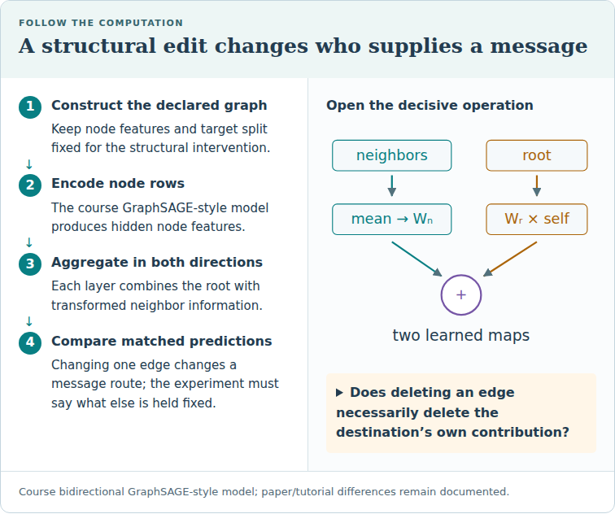

Course bidirectional GraphSAGE-style model; paper/tutorial differences remain documented.

**Trace question:** Does deleting an edge necessarily delete the destination’s own contribution?

**Trace answer:** No. The root branch remains. The intervention removes or changes a neighbor contribution and its normalization.

Research bridge · Elective ◆ · One win: define and test a legal relational perturbation

[B20](https://avistian.github.io/relational/lessons/b20-curriculum-order.html) changed training order while holding exposure and optimization fixed. Now freeze the model and change its database links. The mission asks whether relational structure supplies useful information. That also creates a responsibility: **test how predictions depend on that information being correct**.

[Student notebook](https://avistian.github.io/relational/labs/b21-structural-robustness.ipynb) · [Executed solution](https://avistian.github.io/relational/labs/html/b21-structural-robustness.html) · [Download solution](https://avistian.github.io/relational/labs/solutions/b21-structural-robustness.ipynb) · [Printable reference](https://avistian.github.io/relational/reference/b21-structural-robustness.html) · [Reproduction contract](https://avistian.github.io/relational/labs/b21-reproduction.md)

## 1 · A valid value can still be the wrong value

A **primary key (PK)** identifies a row uniquely. A **foreign key (FK)** stores the primary key of a related row. Referential integrity means every non-null FK refers to an existing permitted parent. Our example permits no nulls. An event's `owner` can reference a real account and still identify the wrong account.

A **functional dependency**, written `session → owner`, means that any two events with the same session must have the same owner. Checking each FK against the account table does not check this cross-row rule. **Temporal eligibility** is another condition: our course permits a parent only if it existed when the event occurred. This stronger event-time rule is part of our declared threat model.

**Worked prerequisite.** Events0 and1 belong to session0. Their owners are both account0. Changing event0's owner to account1 preserves FK existence but breaks `session → owner`. Changing both owners to account1 preserves both conditions. If account1 did not yet exist, the change would still fail the time rule. Recall the availability boundary from [B19b](https://avistian.github.io/relational/lessons/b19b-forecasting-contracts.html); the precise event-time rule here is a separate declared constraint.

> **In plain terms.** “The database accepts this ID” is weaker than “this edit obeys every rule of the experiment,” and both are weaker than “the prediction stays good.”

## 2 · Write the threat model before choosing the attack

A **threat model** says what the attacker knows, what they may change, and what counts as damage. Our white-box evaluator knows the fixed model weights, features and query answers. It may edit owner FKs; it may not edit features, answers, row IDs, session IDs or timestamps. The query cutoff is10. Parent account3 arrives at12 and cannot be used.

An **evasion attack** changes the input to a frozen model. A **poisoning attack** changes data used to train a model. This lesson studies evasion only. Knowing the answers makes this a strong supervised stress test. It is not a claim that a deployed attacker necessarily has those answers.

**Budget unit.** One edit means one changed database FK cell. A graph often stores both child→parent and parent→child edges. Replacing one FK removes two directed edges and inserts two directed edges, but still costs one database edit. Moving the two-row session costs two edits. Count the final changed cells once; do not count API calls or repeated rewrites.

**Manual intervention:** compare owners[0,0,1,2,1,2] with[1,1,1,2,1,2]. Count changed cells, check session0 and timestamps, then recompute means.

**Try it.** Move session0 to account1 with budget1, then budget2. Next move only event0. Finally choose the future account. Before each reveal, predict which constraint rejects the proposal. Features and event values never change.

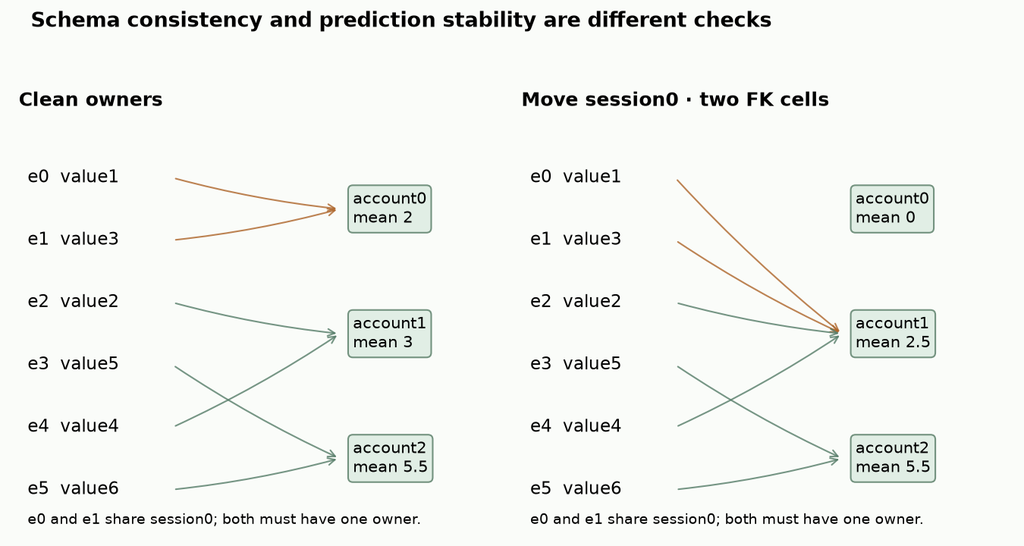

The same feature values follow different valid owner links; two cells change together. On narrow screens, scroll horizontally.

## 3 · Model architecture: how a link changes a prediction

A **heterogeneous graph** has different node and edge types. Here the types are events and accounts. **Message passing** makes a node read vectors from its neighbors. GraphSAGE combines a node's own vector with an aggregate of those neighbor vectors. Two rounds let information travel along two edges. The [paper's model](https://arxiv.org/html/2607.07089v1#S6.SS3) is a heterogeneous GraphSAGE model; its public tutorial includes tabular and temporal encoders before graph propagation.

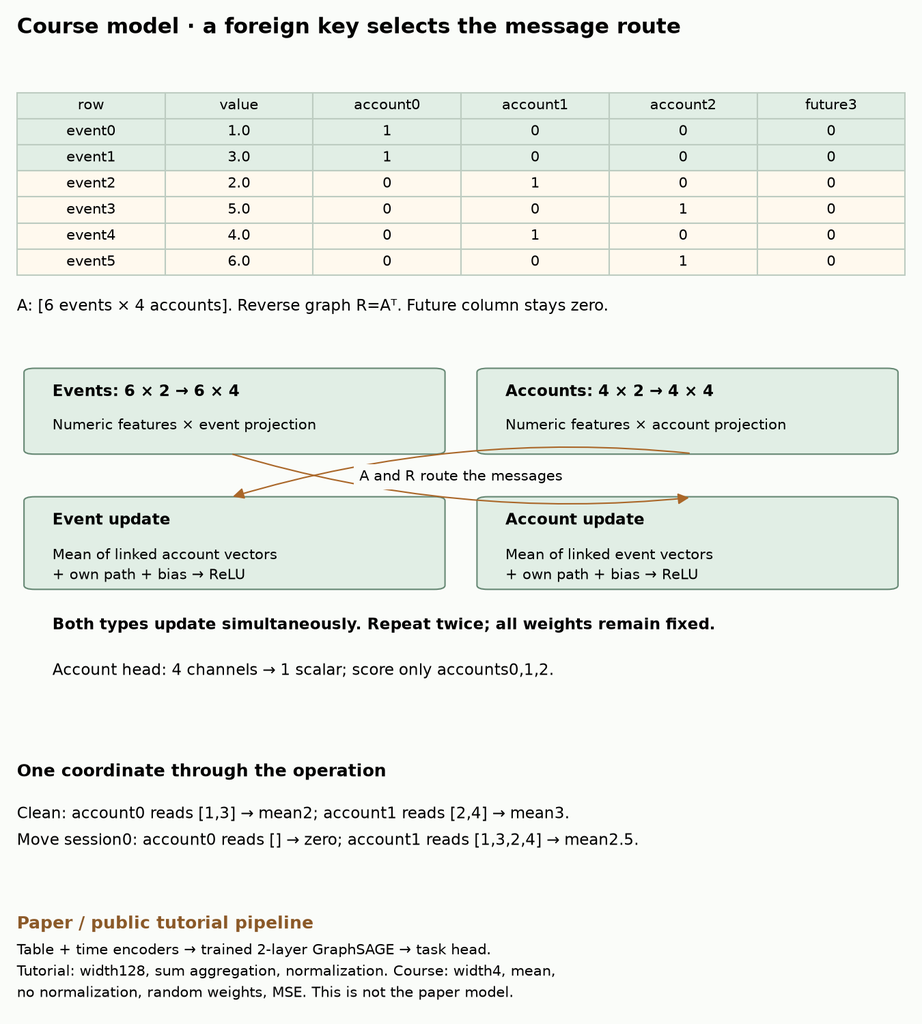

Course bidirectional GraphSAGE-style forward pass; paper/tutorial differences labeled. On narrow screens, scroll horizontally.

**Course inputs.** Events carry two numeric features, beginning with values1,3,2,5,4,6. Accounts carry two fixed numeric features. Separate2×4 projection matrices map each type into four channels. Our four-channel vectors are learned-model-shaped representations, but their weights are randomly initialized and frozen: there is no course training.

**One round.** Let A be a6×4 matrix whose entry A[i,j] is1 when event i belongs to account j and0 otherwise. Let R=Aᵀ be the4×6 reverse matrix; the superscript means transpose, swapping rows and columns. An account reads the mean of its linked event vectors. An event reads its linked account vector. Each type adds its own transformed vector, its transformed neighbor mean and a bias, then applies ReLU, which replaces negative coordinates with zero. Both types update simultaneously from the previous round.

**Worked aggregation.** Account0 initially reads values1 and3, so their mean is2. Account1 reads2 and4, mean3. Move session0's two events to account1: account0 has no neighbors, defined to contribute a zero vector; account1 now reads1,3,2,4, mean2.5. This is one displayed feature coordinate, not the network's final prediction.

**Output.** Repeat message passing twice. A linear head maps each account's four-vector to a scalar prediction. Score only query accounts0,1,2. Account3's features cannot influence them through any legal graph. A test changes those future features by a huge amount and requires unchanged eligible predictions.

> **Scope check.** The course uses width4, mean aggregation, no layer normalization, fixed random weights and squared loss. The source tutorial uses width128, sum aggregation and trained weights for the selected regression task. The diagram labels these differences. Our evidence concerns finite model sensitivity, not the paper's accuracy or learned relational generalization.

## 4 · Score the whole replacement, not just the new edge

The **loss** measures disagreement with known answers. Our mean squared error (MSE) averages (prediction−answer)² over the three queries. Larger means more damage in this experiment. The paper's selected target uses mean absolute error (MAE), which averages absolute differences instead. These are different units and objectives.

A **gradient** measures the local rate of change of loss with an input. Integer IDs have no useful ordinary gradient. Introduce continuous edge weights, then differentiate the graph calculation with respect to them. An existing edge starts at1 and a candidate edge starts at0. Our weighted mean divides by the sum of incoming weights, with an explicit zero-neighborhood rule. These fractional weights are a scoring device, not database edits.

**Worked direction.** Suppose a child's old forward-edge gradient is2 and the new gradient is5. The reverse-edge gradients are7 and11. Removing the old edges contributes−2−7. Adding the new edges contributes5+11. The predicted first-order loss change is7. Looking only at the new edges gives16 and ranks the wrong quantity.

For a proposed adjacency change Δ=A_new−A_old, the full linear score is the sum of G_forward×Δ plus G_reverse×Δᵀ over all entries. Here G denotes a matrix of gradients and × means entrywise multiplication before summing. A coupled edit adds the contributions of every changed row. The public source also subtracts old-edge gradients; read the actual implementation alongside the paper's candidate-score notation. [Source](https://avistian.github.io/relational/labs/sources/b21/utils.py)

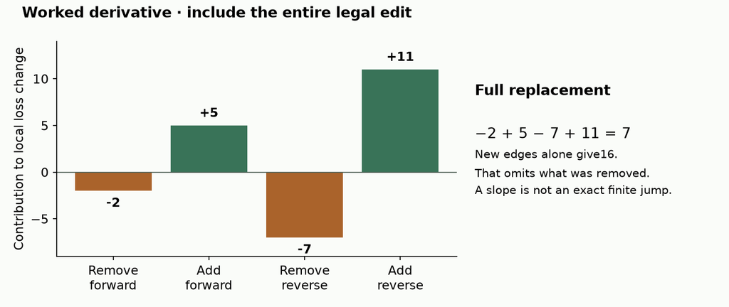

Removal and insertion in both directions yield total slope7, not16. On narrow screens, scroll horizontally.

**Local is not exact.** ReLU boundaries, changing neighbor means, and two-round propagation make loss nonlinear. A large local slope need not identify the most damaging discrete edit. We verify30 admissible directions by a small positive finite difference: nudge along the direction, measure the loss change, divide by the nudge size, and compare with the gradient. Passing that check verifies local derivatives, not the attack's global optimality.

## 5 · Enumerate the finite experiment completely

**Held fixed:** database features and answers, admissible destinations, model weights within each seed, budget definition and loss. **Varied:** edit selection method and allowed FK-cell budget. **Measured:** actual changed cells, all query predictions, attacked MSE and regret. Regret is the exhaustive worst-case loss minus the method's achieved loss; zero means the method found a worst case in this finite universe.

There are three seeds0/1/2, budgets0/1/2, and three methods. That gives27 comparison conditions and81 reported query predictions. Five sessions each have two alternative legal parents:10 atomic session/destination edits. The two-row session costs2; the four other sessions cost1. Within budget2, count the clean state,8 single-row changes,2 coupled changes and24 two-single-row combinations:35 states. With three models, score105 model/state pairs, or315 output coordinates, before selecting results.

| Method | Selection rule | What the result establishes |
| --- | --- | --- |
| Random | One uniform draw from states using exactly the budget | One paired random baseline draw, not its expectation |
| Gradient | Maximize linear gain over all legal states within the budget | Best local linearized choice in this small universe |
| Exhaustive | Maximize actual loss over all legal states within the budget, including clean | Exact worst case for this finite model and threat set |

Ties favor fewer changed cells, then lexicographic owner assignments. Clean is available to both optimizers, so they need not spend the full allowance. Our gradient selection enumerates feasible directions to isolate linearization error. The paper uses sampled candidates and selection heuristics, which introduce additional search limitations.

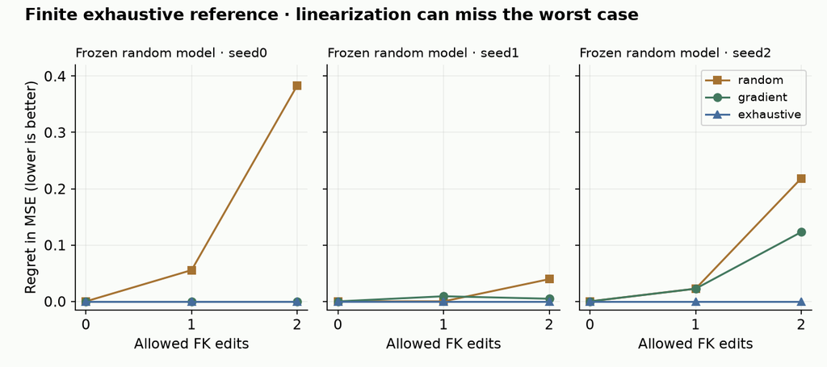

All three seeds and budgets; exhaustive regret is zero by definition. On narrow screens, scroll horizontally.

| Seed | Budget | Random MSE | Gradient MSE | Exhaustive MSE | Exhaustive edits used |
| --- | --- | --- | --- | --- | --- |
| 0 | 0 | 3.629972 | 3.629972 | 3.629972 | 0 |
| 0 | 1 | 3.589556 | 3.645049 | 3.645049 | 1 |
| 0 | 2 | 3.662597 | 4.046013 | 4.046013 | 2 |
| 1 | 0 | 3.671067 | 3.671067 | 3.671067 | 0 |
| 1 | 1 | 3.685567 | 3.676531 | 3.685567 | 1 |
| 1 | 2 | 3.646104 | 3.680894 | 3.685567 | 1 |
| 2 | 0 | 3.709689 | 3.709689 | 3.709689 | 0 |
| 2 | 1 | 3.709689 | 3.709689 | 3.732193 | 1 |
| 2 | 2 | 3.666667 | 3.762107 | 3.885177 | 2 |

**Read the result.** At budget2, the gradient choice matches exhaustive search for seed0 but misses it for seeds1 and2. Seed1's exact worst case uses only one changed FK cell. More permitted edits cannot lower the exhaustive maximum, because the smaller feasible set remains included. A heuristic forced to use more edits can improve or worsen the attack. Do not infer that random never works or that gradients always win from three random-network seeds.

The independent audit uses a separate NumPy forward and enumerates the six individual FK cells instead of the five session choices. It checks every legal state, prediction, loss and method selection. Its output agrees exactly with the saved course prediction coordinates in this runtime. Eight deliberately corrupted reports are rejected. [Numerical evidence](https://avistian.github.io/relational/labs/evidence/b21/diagnostic.json) · [Independent audit](https://avistian.github.io/relational/labs/_verify_b21_results.json)

## 6 · Full reproduction starts with preserving the clean model

Our named historical target is the entire qualifying-position block of Table4 in [Structural Adversarial Attacks on Relational Deep Learning under Integrity Constraints](https://arxiv.org/abs/2607.07089v1). It needs seven methods, five budgets1/25/50/75/100 and five seeds39–43:175 seed conditions. The published training setting has18epochs, two layers, width128, batch512,128neighbors per hop and100candidate samples per source. [Appendix](https://arxiv.org/html/2607.07089v1#A1.SS2)

**What is available.** The pinned author repository provides model/trainer/attack code and a notebook with saved output. We authenticate those bytes and extract all35 selected paper mean/std cells and all35 saved tutorial result rows. The tutorial has one epoch, one seed and budgets1/125/250/375/500. Its current seed loop cannot run as written, so saved outputs are historical notebook contents, not proof that the present cells execute.

**Clean-equivalence test.** Before any attack, the ordinary model and its differentiable wrapper should agree on the same graph. Our current-runtime probe finds four newly introduced root-bias tensors not filled by the permissive weight copy. Maximum embedding differences across three small fixtures are1.422336,0.712215 and1.648367. Zeroing only those biases makes the embeddings match exactly on all three fixtures. That controlled repair isolates this local conversion issue; it does not authenticate the authors' original environment or establish full benchmark equivalence.

**Constraint test.** The released candidate sampler admits future parents on our supplied fixture and does not enforce our coupled-session dependency. Its edit function can produce a graph dictionary that differs from the underlying relation stores. The attackable model reads that dictionary, so the edit is not a no-op; the problem is that database/graph consistency has not been demonstrated. These are bounded tests of released components, not claims that every original experiment violated its rules. [Executed source probes](https://avistian.github.io/relational/labs/evidence/b21/source-probes.json)

> **Scope check.** Selected historical reproduction is **INCOMPLETE_SOURCE_PROTOCOL_GATE / NOT_RUN**. Original checkpoints, exact batches, candidate draws, data identities and dependency versions have not been authenticated. Paper cells and tutorial results use different protocols and are **INCOMPARABLE**. We preserve the complete public source, an executable audit and a command that refuses historical training until the gates are resolved. No epochs or seeds are silently reduced to manufacture a reproduction.

**Why this matters.** Without clean equivalence, an apparent attack effect could include a changed predictor. Without valid database reconstruction, a graph perturbation may not represent any legal database edit. Without identical historical inputs, numerical proximity cannot establish reproduction. [Full contract and commands](https://avistian.github.io/relational/labs/b21-reproduction.md)

## 7 · Build the checks yourself

The standalone notebook has three live functions:

1. `changed_cells`: count final FK cells that differ, including every member of a coupled edit.
2. `validate_assignment`: enforce existing integer parent IDs, session consistency, availability and budget.
3. `direction_score`: include old-edge removal and new-edge insertion in both directions.

Each CHECK rejects a plausible wrong answer. Your functions feed a complete fresh finite rerun and comparison with saved evidence. The full small model and independent oracle are visible in the notebook. The paper lane separately authenticates the archived source and saved output. No repository checkout is required for either default lane.

**Counterfactual exercise.** If the attacker does not know query answers, which selection rules would become unavailable? If you allow only one-row edits, what happens to session0's feasible moves? Change one assumption at a time and report the newly defined universe rather than treating it as the original experiment.

**Exit defense.** Explain why FK validity is insufficient, why a two-row move costs two, why clean-equivalence is necessary, and why a failed attack does not prove a formal robustness guarantee. Exhaustive search gives a guarantee only over this explicitly finite set for these fixed models. It says nothing about other data, other edits or privacy. Near-random privacy-attack success would not prove differential privacy either; that is the alternative B21 route, not an outcome measured here.

Ask the agent a follow-up question or paste your explanation for feedback. Revisit the legal-edit trace tomorrow, the gradient calculation in one week, and the threat-model defense in one month. Author tests do not establish learner mastery.

Next: [B22](https://avistian.github.io/relational/plan/year-5-6-bridge.md#b22) asks whether an intervention on a newer model mechanism supports the claim made about it. Carry forward the same habit: freeze the boundary, alter one thing, and measure the consequence.

## PROVIDED · standalone environment

Default lane: fresh complete finite experiment plus independent saved replay and source/table audit. There is no paper training or model download. Complete the three TODOs before running the later experiment. Tested author versions are recorded in the packet; live Colab is NOT_CHECKED.

```python
# @colab-bootstrap: no repository checkout needed.
import importlib.util, subprocess, sys
missing=[package for module,package in [('numpy','numpy'),('torch','torch'),('bs4','beautifulsoup4')] if importlib.util.find_spec(module) is None]
if missing:subprocess.check_call([sys.executable,'-m','pip','install',*missing])
import base64,copy,hashlib,io,itertools,json,re,zipfile
from pathlib import Path
import numpy as np
import torch
from bs4 import BeautifulSoup
torch.set_num_threads(1)
```

```python
packet=base64.b64decode('UEsDBBQAAAAIAAAARF2AjbPDmSsAAFwSAQAcAAAAZXZpZGVuY2UvYjIxL2Rp…')
assert hashlib.sha256(packet).hexdigest()=='38a9c7f007b28e9098ab0a8e24c6e642779833b4f7e833a9881c0c8dd06e0c89'
root=Path('b21-packet');root.mkdir(exist_ok=True)
with zipfile.ZipFile(io.BytesIO(packet)) as z:
    assert all(not Path(n).is_absolute() and '..' not in Path(n).parts for n in z.namelist())
    z.extractall(root)
manifest={'evidence/b21/mechanism-checks.json': '966be1d02c35e22f10397c3eeabb3f0be55d38850c8f489da84cbcf1bf0ff84c', 'evidence/b21/reproduction.json': '0ef75361f00e39769641eb990977143da9af8647ebcb11c581fb20e1958f1e01', 'evidence/b21/source-probes.json': 'fd97335bb2e960480e4bdb8948eadadf2c9c6b025b1fcd92771d36200f7e40e7', 'evidence/b21/diagnostic.json': '48d8590bbb4171487913d26a24c3e3b910e4e313d6240fa1b06fe9016e572cb0', 'evidence/b21/runtime.json': '1b8f092ea83329132084d1e667ad9bdedb729403070b2f88f3a61780d7ec7342', 'sources/b21/utils.py': 'c5d7125c4eb3f151bc77c94f7db948226084127cd8347179f2ed6a50c79ae1b8', 'sources/b21/tuto.ipynb': 'c75fe72703c9fa0d71fc99a2c5fdf6157e84742ea10f664e90493ef2b87870f8', 'sources/b21/installed-HeteroGraphSAGE.py': '603d5cabaadd1b4b525370e24a2efea77bfcd4da3fb6e314858f6b0da6875e91', 'sources/b21/README.md': '0395aa68942d342cad1b2c627eca50269563790ff714633101e7d7d850f3b381', 'sources/b21/tree.json': '406c2f7abda9a825a7f726431063ea5fc063bb93ae8d7f8208f154de17b3e5c2', 'sources/b21/manifest.json': '40e263907e7f78fb27a82d3dd930f3544aaccc1272928945a6afec5546d0cf4f', 'sources/b21/paper.html': 'd8325c7acfd63c1b8be8b6de64c41295b2ef2d81a13e5d228c916f0e2686e9fd'}
for name,digest in manifest.items():assert hashlib.sha256((root/name).read_bytes()).hexdigest()==digest,name
E=root/'evidence/b21'
print('Authenticated',len(manifest),'source/evidence files')
```

```
Authenticated 12 source/evidence files
```

```python
def fixture():
    return dict(parent_time=[0,1,2,12], child_time=[3,4,5,6,7,8],
                session=[0,0,1,2,3,4], original=[0,0,1,2,1,2], cutoff=10,
                parent_x=[[1.,0.],[0.,1.],[1.,1.],[9.,9.]],
                child_x=[[1.,0.],[3.,1.],[2.,0.],[5.,1.],[4.,0.],[6.,1.]],
                target=[2.,4.,6.], query_ids=[0,1,2])
```

## TODO1 · `changed_cells`

Implement the rule from the lesson. Preserve the signature. Invalid shapes, assignments or budgets should raise ValueError. This function is used by the complete experiment below.

```python
def changed_cells(original, assignment):
    a,b=np.asarray(original),np.asarray(assignment)
    if a.ndim!=1 or a.shape!=b.shape:raise ValueError('FK shape mismatch')
    return int(np.count_nonzero(a!=b))
```

```python
assert changed_cells([0,0,1],[2,2,1])==2
assert changed_cells([0,0],[0,0])==0
try:changed_cells([0],[0,1])
except ValueError:pass
else:raise AssertionError('Mismatched shapes accepted')
print('CHECK: count cells, not coupled operations or directed edges')
```

```
CHECK: count cells, not coupled operations or directed edges
```

## TODO2 · `validate_assignment`

Implement the rule from the lesson. Preserve the signature. Invalid shapes, assignments or budgets should raise ValueError. This function is used by the complete experiment below.

```python
def validate_assignment(data, assignment, budget):
    a=np.asarray(assignment)
    if not isinstance(budget,(int,np.integer)) or budget<0:raise ValueError('Invalid budget')
    if a.shape!=(len(data['original']),) or not np.issubdtype(a.dtype,np.integer):raise ValueError('Integer FK vector required')
    if np.any(a<0) or np.any(a>=len(data['parent_time'])):raise ValueError('Dangling FK')
    for session in set(data['session']):
        owners=a[np.asarray(data['session'])==session]
        if len(set(owners))!=1:raise ValueError('Session -> account dependency violated')
    if np.any(np.asarray(data['parent_time'])[a]>np.asarray(data['child_time'])):raise ValueError('Parent unavailable at event')
    if np.any(np.asarray(data['child_time'])>data['cutoff']):raise ValueError('Future event')
    if changed_cells(data['original'],a)>budget:raise ValueError('FK cell budget exceeded')
    return True
```

```python
d=fixture()
assert validate_assignment(d,d['original'],0)
assert validate_assignment(d,[2,2,1,2,1,2],2)
for a,b in [([2,0,1,2,1,2],2),([2,2,1,2,1,2],1),([3,3,1,2,1,2],2),([4,4,1,2,1,2],2),([-1,-1,1,2,1,2],2),([0.,0.,1.5,2.,1.,2.],2)]:
    try:validate_assignment(d,a,b)
    except ValueError:pass
    else:raise AssertionError('Invalid assignment accepted')
print('CHECK: coupled rule, timestamps, FK existence, type and budget')
```

```
CHECK: coupled rule, timestamps, FK existence, type and budget
```

## TODO3 · `direction_score`

Implement the rule from the lesson. Preserve the signature. Invalid shapes, assignments or budgets should raise ValueError. This function is used by the complete experiment below.

```python
def direction_score(forward_gradient, reverse_gradient, before, after):
    gf,gr,b,a=map(np.asarray,(forward_gradient,reverse_gradient,before,after))
    if b.ndim!=2 or gf.shape!=b.shape or a.shape!=b.shape or gr.shape!=b.T.shape:raise ValueError('Gradient/adjacency shape mismatch')
    delta=a-b
    return float(np.sum(gf*delta)+np.sum(gr*delta.T))
```

```python
gf=np.array([[2.,5.]]);gr=np.array([[7.],[11.]])
a=np.array([[1.,0.]]);b=np.array([[0.,1.]])
assert direction_score(gf,gr,a,b)==7
assert direction_score(gf,gr,a,a)==0
try:direction_score(gf,gr,np.zeros((2,2)),np.zeros((2,2)))
except ValueError:pass
else:raise AssertionError('Bad shapes accepted')
print('CHECK: remove old edges, add new edges, include reverse')
```

```
CHECK: remove old edges, add new edges, include reverse
```

## PROVIDED · graph identities and all legal states

Trace the code against the architecture and frozen contract. There is no training loop: the experiment freezes random weights and changes legal FK assignments.

```python
def adjacency(assignment, n_parent=4):
    a=np.zeros((len(assignment),n_parent),dtype=np.float64)
    a[np.arange(len(assignment)),assignment]=1.
    return a

def legal_states(data, budget):
    groups=sorted(set(data['session']));states=[]
    for owners in itertools.product(range(len(data['parent_time'])),repeat=len(groups)):
        a=[owners[groups.index(g)] for g in data['session']]
        try:validate_assignment(data,a,budget)
        except ValueError:continue
        states.append(a)
    return states

def validate_graph(data, assignment, budget, forward_edges, reverse_edges):
    validate_assignment(data,assignment,budget)
    expected=adjacency(assignment,len(data['parent_time']))
    if not np.array_equal(forward_edges,expected) or not np.array_equal(reverse_edges,expected.T):
        raise ValueError('Graph directions do not match the database')
    return True
```

## PROVIDED · fixed random weights and complete two-layer forward

Trace the code against the architecture and frozen contract. There is no training loop: the experiment freezes random weights and changes legal FK assignments.

```python
def parameters(seed):
    rng=np.random.default_rng(seed);w={}
    for node in ['parent','child']:w['embed_'+node]=rng.normal(0,.4,(2,4))
    for layer in range(2):
        for node in ['parent','child']:
            for path in ['own','neighbor']:w[f'{layer}_{node}_{path}']=rng.normal(0,.4,(4,4))
            w[f'{layer}_{node}_bias']=np.full(4,.2)
    w['head']=rng.normal(0,.4,4);w['head_bias']=3.
    return w

def forward(data, weights, forward_edges, reverse_edges):
    """A[child,parent] and R[parent,child]. Valid discrete graphs have R=A.T.

    Row-normalized weighted means have zero for empty neighborhoods. The
    continuous mask extension normalizes by summed weight, not candidate count.
    Layers update both types simultaneously. Parameters are fixed float64.
    """
    def t(x):return torch.as_tensor(x,dtype=torch.float64)
    p=t(data['parent_x'])@t(weights['embed_parent'])
    c=t(data['child_x'])@t(weights['embed_child'])
    for layer in range(2):
        incoming_parent=forward_edges.T
        incoming_child=reverse_edges.T
        mp=(incoming_parent@c)/incoming_parent.sum(1,keepdim=True).clamp(min=1e-12)
        mc=(incoming_child@p)/incoming_child.sum(1,keepdim=True).clamp(min=1e-12)
        np_=torch.relu(p@t(weights[f'{layer}_parent_own'])+mp@t(weights[f'{layer}_parent_neighbor'])+t(weights[f'{layer}_parent_bias']))
        nc=torch.relu(c@t(weights[f'{layer}_child_own'])+mc@t(weights[f'{layer}_child_neighbor'])+t(weights[f'{layer}_child_bias']))
        p,c=np_,nc
    return (p@t(weights['head'])+t(weights['head_bias']))[data['query_ids']]
```

## PROVIDED · complete paired selection experiment

Trace the code against the architecture and frozen contract. There is no training loop: the experiment freezes random weights and changes legal FK assignments.

```python
def experiment():
    data=fixture();before=adjacency(data['original']);states=legal_states(data,2)
    report=dict(name='B21-FK-STRESS',status='COMPLETE',data=data,seeds=[0,1,2],budgets=[0,1,2],
                methods=['random','gradient','exhaustive'],states=[],conditions=[],weights={},gradients={},
                claim='Finite random-network stress diagnostic; no training, generalization or paper parity')
    target=torch.tensor(data['target'],dtype=torch.float64)
    for seed in report['seeds']:
        w=parameters(seed);report['weights'][str(seed)]={k:np.asarray(v).tolist() for k,v in w.items()}
        a=torch.tensor(before,requires_grad=True);r=torch.tensor(before.T,requires_grad=True)
        clean_pred=forward(data,w,a,r);loss=((clean_pred-target)**2).mean();loss.backward()
        gf,gr=a.grad.numpy(),r.grad.numpy();report['gradients'][str(seed)]=dict(forward=gf.tolist(),reverse=gr.tolist())
        records=[]
        for state in states:
            af=adjacency(state);validate_graph(data,state,2,af,af.T);pred=forward(data,w,torch.tensor(af),torch.tensor(af.T)).detach().numpy()
            row=dict(seed=seed,assignment=state,cost=changed_cells(data['original'],state),prediction=pred.tolist(),
                     loss=float(np.mean((pred-np.asarray(data['target']))**2)),
                     linear_gain=direction_score(gf,gr,before,af))
            records.append(row);report['states'].append(row)
        for budget in report['budgets']:
            feasible=[x for x in records if x['cost']<=budget]
            exact_cost=[x for x in feasible if x['cost']==budget]
            rng=np.random.default_rng(1000+10*seed+budget)
            random=exact_cost[int(rng.integers(len(exact_cost)))]
            # Strict improvement only; ties prefer fewer edits, then lexicographic assignment.
            gradient=min(feasible,key=lambda x:(-x['linear_gain'],x['cost'],x['assignment']))
            exhaustive=min(feasible,key=lambda x:(-x['loss'],x['cost'],x['assignment']))
            for method,row in [('random',random),('gradient',gradient),('exhaustive',exhaustive)]:
                report['conditions'].append(dict(row,method=method,budget=budget,clean_loss=float(loss.detach()),
                    actual_gain=row['loss']-float(loss.detach()),regret=exhaustive['loss']-row['loss']))
    return report
```

```python
fresh=experiment()
saved=json.loads((E/'diagnostic.json').read_text())
assert len(fresh['conditions'])==27 and len(fresh['states'])==105
for actual,reference in zip(fresh['states'],saved['states']):
    assert actual['assignment']==reference['assignment'] and actual['seed']==reference['seed']
    np.testing.assert_allclose(actual['prediction'],reference['prediction'],rtol=1e-10,atol=1e-10)
for actual,reference in zip(fresh['conditions'],saved['conditions']):
    assert actual['assignment']==reference['assignment'] and actual['method']==reference['method']
Path('b21-fresh.json').write_text(json.dumps(fresh,indent=2)+'\n')
print('Fresh finite experiment COMPLETE:105 model/states,27 comparisons')
for row in fresh['conditions']:
    if row['budget']==2:print(row['seed'],row['method'],'MSE',round(row['loss'],6),'edits',row['cost'],'regret',round(row['regret'],6))
```

```
Fresh finite experiment COMPLETE:105 model/states,27 comparisons
0 random MSE 3.662597 edits 2 regret 0.383416
0 gradient MSE 4.046013 edits 2 regret 0.0
0 exhaustive MSE 4.046013 edits 2 regret 0.0
1 random MSE 3.646104 edits 2 regret 0.039463
1 gradient MSE 3.680894 edits 2 regret 0.004673
1 exhaustive MSE 3.685567 edits 1 regret 0.0
2 random MSE 3.666667 edits 2 regret 0.21851
2 gradient MSE 3.762107 edits 2 regret 0.12307
2 exhaustive MSE 3.885177 edits 2 regret 0.0
```

## CHECK · independent full NumPy replay

Enumerate six independent FK cells and reject illegal states. Recompute all105 model/state predictions without PyTorch or the course forward function.

```python
def numpy_forward(data,weights,owners):
    p=np.array(data['parent_x'])@np.array(weights['embed_parent'])
    c=np.array(data['child_x'])@np.array(weights['embed_child'])
    for layer in range(2):
        pp=[];cc=[]
        for j in range(len(p)):
            neighbors=[c[i] for i,owner in enumerate(owners) if owner==j]
            mean=np.mean(neighbors,axis=0) if neighbors else np.zeros(c.shape[1])
            pp.append(np.maximum(0,p[j]@weights[f'{layer}_parent_own']+mean@weights[f'{layer}_parent_neighbor']+weights[f'{layer}_parent_bias']))
        for i,owner in enumerate(owners):
            cc.append(np.maximum(0,c[i]@weights[f'{layer}_child_own']+p[owner]@weights[f'{layer}_child_neighbor']+weights[f'{layer}_child_bias']))
        p,c=np.array(pp),np.array(cc)
    return (p@np.array(weights['head'])+weights['head_bias'])[data['query_ids']]

def audit(report):
    d=report['data'];original=d['original']
    assert d==dict(parent_time=[0,1,2,12],child_time=[3,4,5,6,7,8],session=[0,0,1,2,3,4],original=[0,0,1,2,1,2],cutoff=10,parent_x=[[1.,0.],[0.,1.],[1.,1.],[9.,9.]],child_x=[[1.,0.],[3.,1.],[2.,0.],[5.,1.],[4.,0.],[6.,1.]],target=[2.,4.,6.],query_ids=[0,1,2])
    assert report['seeds']==[0,1,2] and report['budgets']==[0,1,2]
    assert report['methods']==['random','gradient','exhaustive']
    universe=[]
    # Independent enumeration of six FK cells, not five group choices.
    for a in itertools.product(range(4),repeat=6):
        if a[0]!=a[1]:continue
        if any(d['parent_time'][v]>d['child_time'][i] for i,v in enumerate(a)):continue
        if sum(v!=o for v,o in zip(a,original))<=2:universe.append(a)
    assert len(universe)==35
    assert len(report['states'])==105 and len(report['conditions'])==27
    errors=[];scores=[]
    for seed in range(3):
        rows=[x for x in report['states'] if x['seed']==seed]
        assert len(rows)==35 and set(tuple(x['assignment']) for x in rows)==set(universe)
        w={k:np.asarray(v) for k,v in report['weights'][str(seed)].items()}
        clean=numpy_forward(d,w,original);clean_loss=float(np.mean((clean-d['target'])**2))
        gf=np.array(report['gradients'][str(seed)]['forward']);gr=np.array(report['gradients'][str(seed)]['reverse'])
        for x in rows:
            a=x['assignment'];prediction=numpy_forward(d,w,a)
            np.testing.assert_allclose(prediction,x['prediction'],rtol=0,atol=1e-12)
            loss=float(np.mean((prediction-d['target'])**2))
            assert abs(loss-x['loss'])<1e-12
            assert x['cost']==sum(u!=v for u,v in zip(a,original))
            gain=sum(gf[i,new]-gf[i,old]+gr[new,i]-gr[old,i] for i,(old,new) in enumerate(zip(original,a)))
            assert abs(gain-x['linear_gain'])<1e-12
            errors.append(float(np.max(np.abs(prediction-x['prediction']))))
        for budget in [0,1,2]:
            feasible=[x for x in rows if x['cost']<=budget];exact=[x for x in feasible if x['cost']==budget]
            optimal=min(feasible,key=lambda x:(-x['loss'],x['cost'],x['assignment']))
            gradient=min(feasible,key=lambda x:(-x['linear_gain'],x['cost'],x['assignment']))
            rng=np.random.default_rng(1000+10*seed+budget);random=exact[int(rng.integers(len(exact)))]
            conditions=[x for x in report['conditions'] if x['seed']==seed and x['budget']==budget]
            assert len(conditions)==3 and {x['method'] for x in conditions}==set(report['methods'])
            for x in conditions:
                chosen={'random':random,'gradient':gradient,'exhaustive':optimal}[x['method']]
                for k in ['assignment','prediction','loss','cost','linear_gain']:assert x[k]==chosen[k],k
                assert abs(x['clean_loss']-clean_loss)<1e-12
                assert abs(x['actual_gain']-(chosen['loss']-clean_loss))<1e-12
                assert abs(x['regret']-(optimal['loss']-chosen['loss']))<1e-12
                assert x['regret']>=-1e-12
                scores.append({k:x[k] for k in ['seed','budget','method','loss','regret','cost']})
    return dict(status='PASS',independent_states=105,prediction_coordinates=315,conditions=27,
                max_prediction_error=max(errors),scores=scores)
```

```python
verified=audit(saved)
assert audit(fresh)['status']=='PASS'
Path('b21-replay.json').write_text(json.dumps(verified,indent=2)+'\n')
print({k:v for k,v in verified.items() if k!='scores'})
```

```
{'status': 'PASS', 'independent_states': 105, 'prediction_coordinates': 315, 'conditions': 27, 'max_prediction_error': 0.0}
```

## CHECK · primary source and saved tutorial output

Authenticate the archived files, extract all35 printed target cells and35 tutorial result rows. Their training/budget/seed settings differ. This is a source/output audit, not fresh paper inference.

```python
def replay(source_dir):
    s=Path(source_dir);manifest=json.loads((s/'manifest.json').read_text())
    for row in manifest['files']:
        assert hashlib.sha256((s/row['file']).read_bytes()).hexdigest()==row['sha256'],'SOURCE_HASH_MISMATCH '+row['file']
    html=BeautifulSoup((s/'paper.html').read_text(),'html.parser')
    for math in html.find_all('math'):math.replace_with(math.get('alttext',''))
    selected=[];task=None
    for row in html.find(id='S6.T4').select('tr'):
        cells=[c.get_text(' ',strip=True) for c in row.find_all(['td','th'])]
        if not cells:continue
        if cells[0] in ['driver-dnf','driver-top3','driver-position','qualifying-position']:task=cells.pop(0)
        if task!='qualifying-position':continue
        method=cells[0]
        for budget,value in zip([1,25,50,75,100],cells[1:]):
            numbers=re.findall(r'\d+\.\d+',value)
            assert len(numbers)==2
            selected.append(dict(method=method,budget=budget,mean=float(numbers[0]),std=float(numbers[1])))
    assert len(selected)==35
    notebook=json.loads((s/'tuto.ipynb').read_text());table=BeautifulSoup(''.join(notebook['cells'][11]['outputs'][0]['data']['text/html']),'html.parser')
    header=[c.get_text(' ',strip=True) for c in table.select('thead tr')[-1].select('th')][1:]
    saved=[]
    for tr in table.select('tbody tr'):
        values=[c.get_text(' ',strip=True) for c in tr.select('td')];assert len(values)==len(header)
        saved.append(dict(zip(header,values)))
    assert len(saved)==35 and {int(x['budget']) for x in saved}=={1,125,250,375,500}
    assert all(x['n_seeds']=='1' and x['n_batches']=='1' and x['n_runs']=='1' for x in saved)
    methods={'Random':'random','Random + exact rerank':'random_exact','Gradient raw':'gradient_raw_only','Gradient z-score':'gradient_global_z_only','Gradient robust z-score':'gradient_robust_z_only','Gradient min-max relation':'gradient_minmax_relation','Gradient + exact rerank':'gradient_exact'}
    comparison=[]
    for row in selected:
        if row['budget']!=1:continue
        record=next(x for x in saved if x['method']==methods[row['method']] and x['budget']=='1')
        comparison.append(dict(method=row['method'],budget=1,paper=row['mean'],tutorial=float(record['attacked_metric_mean']),same_protocol=False))
    assert len(comparison)==7
    return dict(status='COMPLETE_SOURCE_AND_SAVED_OUTPUT_AUDIT',paper_target='Table4 qualifying-position, 175 seed/method/budget conditions',
       selected_printed_cells=selected,saved_tutorial_rows=saved,common_budget_comparison=comparison,
       historical_status='INCOMPLETE_SOURCE_PROTOCOL_GATE',historical_execution='NOT_RUN',
       blockers=['Tutorial has one epoch/seed and different budgets; historical checkpoints/batches/environment absent from pinned tree.',
                 'Literal evaluation seed loop uses a list as a dict key; saved outputs do not come from a clean execution of current cells.',
                 'Clean model conversion fails in current-runtime probes; strict=False leaves new root biases initialized.',
                 'Candidate generation alone does not enforce temporal availability or coupled functional dependencies.',
                 'Original fitted predictions and per-seed attack artifacts are not supplied by this pinned repository.'],
       boundaries='Transcribed paper summaries and stale one-run tutorial output are not independently reproduced paper results. Full training and whole paper NOT_RUN.')
```

```python
paper_report=replay(root/'sources/b21')
assert paper_report==json.loads((E/'reproduction.json').read_text())
Path('b21-paper-replay.json').write_text(json.dumps(paper_report,indent=2)+'\n')
print(paper_report['status'],paper_report['historical_status'])
for row in paper_report['common_budget_comparison']:print(row)
```

```
COMPLETE_SOURCE_AND_SAVED_OUTPUT_AUDIT INCOMPLETE_SOURCE_PROTOCOL_GATE
{'method': 'Random', 'budget': 1, 'paper': 0.9941, 'tutorial': 6.718703, 'same_protocol': False}
{'method': 'Random + exact rerank', 'budget': 1, 'paper': 0.9941, 'tutorial': 6.718706, 'same_protocol': False}
{'method': 'Gradient raw', 'budget': 1, 'paper': 0.9949, 'tutorial': 6.718713, 'same_protocol': False}
{'method': 'Gradient z-score', 'budget': 1, 'paper': 0.9949, 'tutorial': 6.718709, 'same_protocol': False}
{'method': 'Gradient robust z-score', 'budget': 1, 'paper': 0.9951, 'tutorial': 6.718709, 'same_protocol': False}
{'method': 'Gradient min-max relation', 'budget': 1, 'paper': 0.9949, 'tutorial': 6.718713, 'same_protocol': False}
{'method': 'Gradient + exact rerank', 'budget': 1, 'paper': 0.9953, 'tutorial': 6.718709, 'same_protocol': False}
```

## EXIT · defend the boundary

Explain why existing IDs are insufficient, why two coupled rows cost two, and why the differentiable model must match the clean one. Identify which methods require query answers. A finite exact search establishes only the worst case in its declared set. Submit your explanation for feedback; learner status remains PENDING_WRITTEN_DEFENSE.

## Historical execution gate

The named Table4 target requires authenticated original identities and verified source behavior. `--fresh` on the repository reproduction operator refuses execution while these are unresolved. The complete author code follows for inspection, not automatic execution. A repaired current release would be a separate reconstruction. Paid computeUSD0; no paper training has run.

```python
RUN_HISTORICAL_PAPER=False
if RUN_HISTORICAL_PAPER:raise RuntimeError('NOT_RUN: INCOMPLETE_SOURCE_PROTOCOL_GATE. Resolve b21-reproduction.md before training.')
```

## Source-probe evidence · current runtime

The packet contains executed source probes. These are not rerun by the default notebook because PyG/RelBench are optional dependencies for that separate operator.

```python
probes=json.loads((E/'source-probes.json').read_text())
print(probes['versions'])
for row in probes['clean_conversion']:print('seed',row['seed'],'clean error',row['max_clean_embedding_error'],'zero-new-bias error',row['zero_new_bias_error'])
print('Saved current-runtime probes; original-paper identity remains unresolved')
```

```
{'torch': '2.13.0+cpu', 'torch-geometric': '2.8.0.post1', 'relbench': '1.1.0'}
seed 0 clean error 1.422336459159851 zero-new-bias error 0.0
seed 1 clean error 0.7122153043746948 zero-new-bias error 0.0
seed 2 clean error 1.6483668088912964 zero-new-bias error 0.0
Saved current-runtime probes; original-paper identity remains unresolved
```

## Appendix · complete original model, trainer and attacks

Unmodified author `code/utils.py`, pinned commit1bc60c7eee605fddbb0975a1c28c64ecc8ce515a. This readable source is archived inside the authenticated packet. It is not the course implementation and is not executed by this appendix.

**Read the complete original Python source**

```
import os
import time
import math
import json
import copy
import random
import argparse
from datetime import datetime
from dataclasses import dataclass, field
from typing import Any, Dict, List, Optional, Tuple, Literal

import numpy as np
import pandas as pd
from tqdm import tqdm
import matplotlib.pyplot as plt

import torch
import torch.nn.functional as F
from torch import Tensor, nn
from torch.nn import Embedding, ModuleDict

from sentence_transformers import SentenceTransformer

from relbench.datasets import get_dataset
from relbench.tasks import get_task
from relbench.modeling.utils import get_stype_proposal
from relbench.modeling.graph import get_node_train_table_input, make_pkey_fkey_graph
from relbench.modeling.nn import HeteroEncoder, HeteroGraphSAGE, HeteroTemporalEncoder
from torch.nn import BCEWithLogitsLoss

from torch_frame.config.text_embedder import TextEmbedderConfig
from torch_frame.data.stats import StatType
from collections import Counter

from torch_geometric.data import HeteroData
from torch_geometric.loader import NeighborLoader
from torch_geometric.nn import MLP, MessagePassing, HeteroConv
from torch_geometric.typing import NodeType
from torch_geometric.seed import seed_everything


#####################################
##############  Models ##############
#####################################

class GloveTextEmbedding:
    def __init__(self, device: Optional[str] = None):
        self.model = SentenceTransformer(
            'sentence-transformers/average_word_embeddings_glove.6B.300d',
            device=device,
        )

    def __call__(self, sentences: List[str]) -> Tensor:
        return torch.from_numpy(self.model.encode(sentences))



class Model(torch.nn.Module):
    def __init__(
        self,
        data: HeteroData,
        col_stats_dict: Dict[str, Dict[str, Dict[StatType, Any]]],
        num_layers: int,
        channels: int,
        out_channels: int,
        aggr: str,
        norm: str,
        shallow_list: List[NodeType] = [],
        id_awareness: bool = False,
    ):
        super().__init__()
        self.encoder = HeteroEncoder(
            channels=channels,
            node_to_col_names_dict={node_type: data[node_type].tf.col_names_dict for node_type in data.node_types},
            node_to_col_stats=col_stats_dict,
        )
        self.temporal_encoder = HeteroTemporalEncoder(
            node_types=[node_type for node_type in data.node_types if 'time' in data[node_type]],
            channels=channels,
        )
        self.gnn = HeteroGraphSAGE(
            node_types=data.node_types,
            edge_types=data.edge_types,
            channels=channels,
            aggr=aggr,
            num_layers=num_layers,
        )
        self.head = MLP(channels, out_channels=out_channels, norm=norm, num_layers=1)
        self.embedding_dict = ModuleDict({node: Embedding(data.num_nodes_dict[node], channels) for node in shallow_list})
        self.id_awareness_emb = torch.nn.Embedding(1, channels) if id_awareness else None
        self.reset_parameters()

    def reset_parameters(self):
        self.encoder.reset_parameters()
        self.temporal_encoder.reset_parameters()
        self.gnn.reset_parameters()
        self.head.reset_parameters()
        for embedding in self.embedding_dict.values():
            torch.nn.init.normal_(embedding.weight, std=0.1)
        if self.id_awareness_emb is not None:
            self.id_awareness_emb.reset_parameters()

    def forward(self, batch: HeteroData, entity_table: NodeType) -> Tensor:
        seed_time = batch[entity_table].seed_time
        x_dict = self.encoder(batch.tf_dict)
        rel_time_dict = self.temporal_encoder(seed_time, batch.time_dict, batch.batch_dict)
        for node_type, rel_time in rel_time_dict.items():
            x_dict[node_type] = x_dict[node_type] + rel_time
        for node_type, embedding in self.embedding_dict.items():
            x_dict[node_type] = x_dict[node_type] + embedding(batch[node_type].n_id)
        x_dict = self.gnn(
            x_dict,
            batch.edge_index_dict,
            batch.num_sampled_nodes_dict,
            batch.num_sampled_edges_dict,
        )
        return self.head(x_dict[entity_table][: seed_time.size(0)])


class WeightedSAGEConv(MessagePassing):
    def __init__(self, in_channels, out_channels, aggr='mean'):
        super().__init__(aggr=aggr)
        if isinstance(in_channels, int):
            in_channels = (in_channels, in_channels)
        self.lin_l = nn.Linear(in_channels[0], out_channels)
        self.lin_r = nn.Linear(in_channels[1], out_channels)

    def forward(self, x, edge_index, edge_weight=None):
        if isinstance(x, torch.Tensor):
            x = (x, x)
        x_src, x_dst = x
        if edge_weight is None:
            edge_weight = x_src.new_ones(edge_index.size(1))
        out = self.propagate(edge_index, x=(x_src, x_dst), edge_weight=edge_weight)
        out = self.lin_l(out) + self.lin_r(x_dst)
        return out

    def message(self, x_j, edge_weight):
        return edge_weight.view(-1, 1) * x_j

class AttackableHeteroGraphSAGE(nn.Module):
    def __init__(self, node_types, edge_types, channels, aggr='sum', num_layers=2):
        super().__init__()
        self.convs = nn.ModuleList()
        self.norms = nn.ModuleList()
        for _ in range(num_layers):
            conv = HeteroConv(
                {edge_type: WeightedSAGEConv((channels, channels), channels, aggr=aggr) for edge_type in edge_types},
                aggr='sum',
            )
            self.convs.append(conv)
            self.norms.append(nn.ModuleDict({node_type: nn.LayerNorm(channels) for node_type in node_types}))

    def forward(self, x_dict, edge_index_dict, edge_weight_dict=None, num_sampled_nodes_dict=None, num_sampled_edges_dict=None):
        if edge_weight_dict is None:
            edge_weight_dict = {}
        for conv, norm_dict in zip(self.convs, self.norms):
            x_dict = conv(x_dict, edge_index_dict, edge_weight_dict=edge_weight_dict)
            x_dict = {k: norm_dict[k](x) for k, x in x_dict.items()}
            x_dict = {k: x.relu() for k, x in x_dict.items()}
        return x_dict
```

```
class AttackableModel(nn.Module):
    def __init__(self, base_model, attackable_gnn):
        super().__init__()
        self.encoder = base_model.encoder
        self.temporal_encoder = base_model.temporal_encoder
        self.head = base_model.head
        self.embedding_dict = getattr(base_model, 'embedding_dict', None)
        self.gnn = attackable_gnn

    def forward(self, batch, entity_table, edge_weight_dict=None, edge_index_dict=None):
        seed_time = batch[entity_table].seed_time
        x_dict = self.encoder(batch.tf_dict)
        rel_time_dict = self.temporal_encoder(seed_time, batch.time_dict, batch.batch_dict)
        for node_type in x_dict:
            if node_type in rel_time_dict:
                x_dict[node_type] = x_dict[node_type] + rel_time_dict[node_type]
        if self.embedding_dict is not None:
            for node_type, emb in self.embedding_dict.items():
                x_dict[node_type] = x_dict[node_type] + emb(batch[node_type].n_id)
        if edge_index_dict is None:
            edge_index_dict = batch.edge_index_dict
        x_dict = self.gnn(
            x_dict,
            edge_index_dict,
            edge_weight_dict=edge_weight_dict,
            num_sampled_nodes_dict=getattr(batch, 'num_sampled_nodes_dict', None),
            num_sampled_edges_dict=getattr(batch, 'num_sampled_edges_dict', None),
        )
        return self.head(x_dict[entity_table][: seed_time.size(0)])




def build_attackable_model(base_model, data, channels, aggr, num_layers):
    attackable_gnn = AttackableHeteroGraphSAGE(
        node_types=list(data.node_types),
        edge_types=list(data.edge_types),
        channels=channels,
        aggr=aggr,
        num_layers=num_layers,
    )
    return AttackableModel(base_model, attackable_gnn)

######################################
##############  Helpers ##############
######################################


def log(msg: str) -> None:
    print(f"[{datetime.now().strftime('%Y-%m-%d %H:%M:%S')}] {msg}", flush=True)

def ensure_dir(path: str) -> None:
    os.makedirs(path, exist_ok=True)

def parse_float_list(s: str) -> List[float]:
    return [float(x.strip()) for x in s.split(',') if x.strip()]

def parse_int_list(s: str) -> List[int]:
    return [int(x.strip()) for x in s.split(',') if x.strip()]

def set_global_seed(seed: int) -> None:
    random.seed(seed)
    np.random.seed(seed)
    torch.manual_seed(seed)
    seed_everything(seed)

def safe_get_dataset(name: str, root_dir: str = './data', download: bool = True):
    """RelBench API compatibility: some versions accept root=, some do not."""
    try:
        return get_dataset(name, root=root_dir, download=download)
    except TypeError:
        return get_dataset(name, download=download)

def safe_get_task(dataset_name: str, task_name: str, root_dir: str = './data', download: bool = True):
    """RelBench API compatibility: some versions accept root=, some do not."""
    try:
        return get_task(dataset_name, task_name, root=root_dir, download=download)
    except TypeError:
        return get_task(dataset_name, task_name, download=download)

def safe_get_task_table(task, split: str):
    """RelBench API compatibility: new versions expose task.get_table(split)."""
    if hasattr(task, 'get_table'):
        return task.get_table(split)
    return getattr(task, f'{split}_table')

def infer_task_type(task_name: str, task=None) -> str:
    if task_name in {'driver-dnf', 'driver-top3'}:
        return 'classification'
    return 'regression'

def prediction_for_eval(raw_pred: Tensor, task_type: str) -> Tensor:
    raw_pred = raw_pred.view(-1) if raw_pred.size(-1) == 1 else raw_pred
    if task_type == 'classification':
        return torch.sigmoid(raw_pred.float())
    return raw_pred


######################################
##############   Main   ##############
######################################



def get_y_from_batch(batch, entity_table):
    assert "y" in batch[entity_table], (
        f"No y in batch[{entity_table}]. "
        f"Available keys: {batch[entity_table].keys()}"
    )
    return batch[entity_table].y.view(-1)


def regression_mae_on_batch(model, batch, entity_table):
    model.eval()
    with torch.no_grad():
        pred = model(batch, entity_table).view(-1)
        y = get_y_from_batch(batch, entity_table).to(pred.device).float().view(-1)

        n = min(pred.numel(), y.numel())
        return float(torch.mean(torch.abs(pred[:n] - y[:n])).item())


def classification_bce_on_batch(model, batch, entity_table):
    model.eval()
    with torch.no_grad():
        logits = model(batch, entity_table).view(-1)
        y = get_y_from_batch(batch, entity_table).to(logits.device).float().view(-1)

        n = min(logits.numel(), y.numel())
        return float(F.binary_cross_entropy_with_logits(logits[:n], y[:n]).item())


def classification_accuracy_on_batch(model, batch, entity_table):
    model.eval()
    with torch.no_grad():
        logits = model(batch, entity_table).view(-1)
        y = get_y_from_batch(batch, entity_table).to(logits.device).float().view(-1)

        n = min(logits.numel(), y.numel())
        pred = (logits[:n] >= 0).float()
        acc = (pred == y[:n]).float().mean()

        return float(acc.item())


def eval_metric_on_batch(model, batch, entity_table, task_type="regression", metric_name=None):
    if task_type == "regression":
        if metric_name is None:
            metric_name = "mae"
        if metric_name == "mae":
            return regression_mae_on_batch(model, batch, entity_table)
        raise ValueError(f"Unknown regression metric: {metric_name}")

    if task_type == "classification":
        if metric_name is None:
            metric_name = "accuracy"
        if metric_name == "accuracy":
            return classification_accuracy_on_batch(model, batch, entity_table)
        if metric_name == "bce":
            return classification_bce_on_batch(model, batch, entity_table)
        raise ValueError(f"Unknown classification metric: {metric_name}")
```

```
    raise ValueError(f"Unknown task_type: {task_type}")


# Backward compatibility avec ton ancien code regression.
def mae_on_batch(model, batch, entity_table):
    return regression_mae_on_batch(model, batch, entity_table)


######################################
##############   Main + ##############
######################################



def _build_edge_lookup(edge_index):
    src, dst = edge_index
    return {(int(src[e]), int(dst[e])): int(e) for e in range(edge_index.size(1))}

def apply_forward_rewirings(batch, attacked_relation, selected_rewirings, reverse_relation=None):
    new_batch = copy.deepcopy(batch)
    new_batch.edge_index_dict = dict(batch.edge_index_dict)

    edge_index = batch.edge_index_dict[attacked_relation].clone()

    # attacked_relation = child -> parent
    # row: child fixed, old_dst -> new_dst
    lookup = _build_edge_lookup(edge_index)

    for row in selected_rewirings:
        child = int(row["child"])
        old_dst = int(row["old_dst"])
        new_dst = int(row["new_dst"])

        pos = lookup.get((child, old_dst), None)
        if pos is not None:
            edge_index[1, pos] = new_dst

    new_batch.edge_index_dict[attacked_relation] = edge_index

    # Update reverse relation: parent -> child
    if reverse_relation is not None and reverse_relation in batch.edge_index_dict:
        rev_edge_index = batch.edge_index_dict[reverse_relation].clone()
        rev_lookup = _build_edge_lookup(rev_edge_index)

        for row in selected_rewirings:
            child = int(row["child"])
            old_dst = int(row["old_dst"])
            new_dst = int(row["new_dst"])

            # old reverse edge: old_parent -> child
            pos = rev_lookup.get((old_dst, child), None)
            if pos is not None:
                # new reverse edge: new_parent -> child
                rev_edge_index[0, pos] = new_dst

        new_batch.edge_index_dict[reverse_relation] = rev_edge_index

    return new_batch


def default_reverse_relation(edge_type):
    src, rel, dst = edge_type
    if rel.startswith('rev_'):
        return (dst, rel[len('rev_'):], src)
    return (dst, f'rev_{rel}', src)



def gradient_order_from_score_info(score_info, topk_per_child=1):
    """Return a global proposal order from a ranked top-k-per-child pool.

    IMPORTANT: this returns proposals, not necessarily final DB edits.  When
    applying inside one local batch, we keep at most one final edit per child.
    In the future global reconstruction stage, top-k gives backup proposals
    when batch-level proposals conflict.
    """
    topk_per_child = max(1, int(topk_per_child))
    pool = score_info.get('scored_rewirings_all', [])
    if not pool:
        pool = score_info.get('scored_rewirings', [])
    rows = [r for r in pool if int(r.get('rank_within_child', 1)) <= topk_per_child]
    rows = sorted(rows, key=lambda x: x.get('score', x.get('score_raw', -np.inf)), reverse=True)
    return rows



def get_default_relations():
    # All reverse FK->PK relations in rel-f1 that can be rewired at graph level.
    # We attack the reverse direction because each child tuple has exactly one current parent.
    return [
        ('races', 'rev_f2p_raceId', 'constructor_results'),
        ('constructors', 'rev_f2p_constructorId', 'constructor_results'),
        ('races', 'rev_f2p_raceId', 'results'),
        ('drivers', 'rev_f2p_driverId', 'results'),
        ('constructors', 'rev_f2p_constructorId', 'results'),
        ('races', 'rev_f2p_raceId', 'qualifying'),
        ('drivers', 'rev_f2p_driverId', 'qualifying'),
        ('constructors', 'rev_f2p_constructorId', 'qualifying'),
        ('circuits', 'rev_f2p_circuitId', 'races'),
        ('races', 'rev_f2p_raceId', 'standings'),
        ('drivers', 'rev_f2p_driverId', 'standings'),
        ('races', 'rev_f2p_raceId', 'constructor_standings'),
        ('constructors', 'rev_f2p_constructorId', 'constructor_standings'),
    ]


def _get_num_local_nodes(batch, node_type):
    store = batch[node_type]
    if hasattr(store, 'num_nodes') and store.num_nodes is not None:
        return int(store.num_nodes)
    if hasattr(store, 'n_id'):
        return int(store.n_id.size(0))
    raise ValueError(f'Cannot infer num_nodes for {node_type}')



def summarize(df_all):
    agg_cols = {
        'attacked_delta_mae': ['mean', 'std'],
        'attacked_delta_mse': ['mean', 'std'],
        'attacked_delta_rmse': ['mean', 'std'],
        'attacked_delta_mean_pred': ['mean', 'std'],
        'attacked_delta_target_mean_pred': ['mean', 'std'],
        'attacked_delta_rest_mean_pred': ['mean', 'std'],
        'attacked_delta_target_rest_gap': ['mean', 'std'],
        'attacked_advantage_score': ['mean', 'std'],
        'apply_time_sec': ['mean'],
        'eval_time_sec': ['mean'],
        'total_eval_time_sec': ['mean'],
        'random_order_build_time_sec': ['mean'],
        'n_selected': ['mean'],
        'n_candidate_edges': ['mean'],
    }
    rel_summary = df_all.groupby(['relation', 'method', 'budget_frac']).agg(agg_cols)
    rel_summary.columns = ['_'.join(c).strip('_') for c in rel_summary.columns]
    rel_summary = rel_summary.reset_index()
    global_summary = df_all.groupby(['method', 'budget_frac']).agg(agg_cols)
    global_summary.columns = ['_'.join(c).strip('_') for c in global_summary.columns]
    global_summary = global_summary.reset_index()
    return rel_summary, global_summary






def sample_candidate_support_per_child_vectorized(
    batch,
    attacked_relation,
    max_candidates_per_dst=25,
    include_existing=True,
):
    """
    Candidate sampler for FORWARD FK -> PK relations.

    Convention:
        attacked_relation = (child_table, f2p_fk_name, parent_table)

    Therefore:
        edge_index[0] = child / FK row  = fixed source
        edge_index[1] = parent / PK row = current destination

    A rewiring means:
        keep the child fixed,
        replace its current parent dst by a new candidate parent dst.

    Output layout per child:
        [existing edge, candidate_1, ..., candidate_k]
```

```
    So for each child c:
        candidate_edge_index contains:
            c -> old_parent
            c -> new_parent_1
            ...
            c -> new_parent_k
    """

    edge_index = batch.edge_index_dict[attacked_relation]
    device = edge_index.device
    dtype = edge_index.dtype

    child_type, _, parent_type = attacked_relation

    src_child, dst_parent = edge_index

    num_parent_nodes = _get_num_local_nodes(batch, parent_type)

    # Collect one current parent per child/FK row.
    # In a clean FK relation, each child should have one parent.
    # We still keep the first occurrence for safety.
    seen = set()
    child_ids = []
    old_dsts = []
    old_edge_pos = []

    for e in range(int(edge_index.size(1))):
        child = int(src_child[e])
        if child in seen:
            continue
        seen.add(child)

        child_ids.append(child)
        old_dsts.append(int(dst_parent[e]))
        old_edge_pos.append(e)

    n_child = len(child_ids)

    if n_child == 0 or num_parent_nodes <= 1 or max_candidates_per_dst <= 0:
        empty_edge_index = torch.empty((2, 0), dtype=dtype, device=device)
        empty_mask = torch.empty((0,), dtype=torch.bool, device=device)

        support = {
            "fast": True,
            "orientation": "forward_fk_to_pk",
            "child_type": child_type,
            "parent_type": parent_type,
            "num_parent_nodes": int(num_parent_nodes),
            "n_child": int(n_child),
            "k_eff": 0,
        }

        return empty_edge_index, empty_mask, support

    k_eff = min(int(max_candidates_per_dst), int(num_parent_nodes) - 1)

    child_t = torch.tensor(child_ids, dtype=dtype, device=device)
    old_dst_t = torch.tensor(old_dsts, dtype=dtype, device=device)
    old_edge_pos_t = torch.tensor(old_edge_pos, dtype=torch.long, device=device)

    # Random candidate parents.
    # Shape: [n_child, k_eff]
    cand_dst = torch.randint(
        low=0,
        high=int(num_parent_nodes),
        size=(n_child, k_eff),
        device=device,
        dtype=dtype,
    )

    # Avoid proposing the already-existing parent.
    old_dst_mat = old_dst_t.view(-1, 1).expand_as(cand_dst)
    collision = cand_dst.eq(old_dst_mat)

    if bool(collision.any().item()):
        cand_dst = torch.where(
            collision,
            (cand_dst + 1) % int(num_parent_nodes),
            cand_dst,
        )

    if include_existing:
        # First column = current true edge.
        dst_mat = torch.cat([old_dst_t.view(-1, 1), cand_dst], dim=1)

        # Child source is fixed across all candidate parents.
        src_mat = child_t.view(-1, 1).expand(n_child, k_eff + 1)

        existing_mask = torch.zeros(
            n_child,
            k_eff + 1,
            dtype=torch.bool,
            device=device,
        )
        existing_mask[:, 0] = True

    else:
        dst_mat = cand_dst
        src_mat = child_t.view(-1, 1).expand(n_child, k_eff)

        existing_mask = torch.zeros(
            n_child,
            k_eff,
            dtype=torch.bool,
            device=device,
        )

    candidate_edge_index = torch.stack(
        [
            src_mat.reshape(-1),
            dst_mat.reshape(-1),
        ],
        dim=0,
    )

    support = {
        "fast": True,
        "orientation": "forward_fk_to_pk",

        # Relation metadata.
        "child_type": child_type,
        "parent_type": parent_type,
        "num_parent_nodes": int(num_parent_nodes),

        # Candidate layout metadata.
        "n_child": int(n_child),
        "k_eff": int(k_eff),

        # One row per rewired child.
        "child_ids": child_t.long(),
        "old_dsts": old_dst_t.long(),
        "old_edge_pos": old_edge_pos_t.long(),
        "cand_dsts": cand_dst.long(),
    }

    return candidate_edge_index, existing_mask.reshape(-1), support



def targeted_output_objective(pred, y=None, direction="increase", mode="mae", q=0.75, alpha=0.25):
    pred = pred.view(-1)

    if mode == "mae":
        assert y is not None, "mode='mae' requires y"
        y = y.to(pred.device).float().view(-1)

        n = min(pred.numel(), y.numel())
        obj = F.l1_loss(pred[:n], y[:n])

    elif mode == "bce":
        assert y is not None, "mode='bce' requires y"
        y = y.to(pred.device).float().view(-1)

        n = min(pred.numel(), y.numel())
        obj = F.binary_cross_entropy_with_logits(pred[:n], y[:n])

    elif mode == "mean":
        obj = pred.mean()

    elif mode in ["quantile", "contrastive"]:
        thresh = torch.quantile(pred.detach(), q)
        target = pred[pred >= thresh]
        rest = pred[pred < thresh]

        if target.numel() == 0:
            target = pred

        if mode == "quantile":
            obj = target.mean()
        else:
            rest_mean = rest.mean() if rest.numel() > 0 else pred.mean()
            obj = target.mean() - alpha * rest_mean

    else:
        raise ValueError(mode)

    if direction == "increase":
        return obj

    if direction == "decrease":
        return -obj

    raise ValueError(direction)

def score_targeted_rewirings_once(
    model,
    batch,
    entity_table,
    attacked_relation,
    max_candidates_per_dst=25,
    direction="increase",          # "increase" ou "decrease"
    objective_mode="mean",
    q=0.75,
    alpha=0.25,
    score_norm="raw",
    max_topk_per_child=10,
    verbose=False,
    plot_grad=True,
):
    """
    Score rewiring candidates for FORWARD FK -> PK relations.

    Convention:
        attacked_relation = (child_table, f2p_fk_name, parent_table)

    Rewiring:
        child/FK src is fixed
        parent/PK dst is replaced

    Candidate layout per child:
        [old_parent, cand_1, ..., cand_k]
    """

    model.eval()
    for p in model.parameters():
        p.requires_grad_(False)

    info_out = {
        "status": "unknown",
        "skip_reason": "",
        "relation": str(attacked_relation),
        "scored_rewirings": [],
        "scored_rewirings_all": [],
        "E": 0,
        "n_candidate_edges": 0,
        "candidate_build_time_sec": 0.0,
        "backward_time_sec": 0.0,
        "scoring_time_sec": 0.0,
        "score_total_time_sec": 0.0,
        "score_norm": score_norm,
        "max_topk_per_child": int(max_topk_per_child),
    }
    if attacked_relation not in batch.edge_index_dict:
        info_out.update(status="skip", skip_reason="missing_in_batch")
        return info_out
```

```
    edge_index = batch.edge_index_dict[attacked_relation]
    E = int(edge_index.size(1))

    info_out.update({
        "E": E,
        "num_edges_batch": E,
        "num_unique_src": int(edge_index[0].unique().numel()) if edge_index.numel() else 0,
        "num_unique_dst": int(edge_index[1].unique().numel()) if edge_index.numel() else 0,
    })

    if E == 0:
        info_out.update(status="skip", skip_reason="empty_relation")
        return info_out

    # ------------------------------------------------------------------
    # 1. Build candidates
    # ------------------------------------------------------------------
    t_build = time.time()

    try:
        candidate_edge_index, existing_mask, support = sample_candidate_support_per_child_vectorized(
            batch=batch,
            attacked_relation=attacked_relation,
            max_candidates_per_dst=max_candidates_per_dst,
            include_existing=True,
        )
    except Exception as e:
        candidate_build_time = time.time() - t_build
        info_out.update(
            status="skip",
            skip_reason="candidate_build_failed",
            error=repr(e),
            candidate_build_time_sec=candidate_build_time,
            score_total_time_sec=candidate_build_time,
        )
        return info_out
    print(candidate_edge_index)
    candidate_build_time = time.time() - t_build

    n_candidate_edges = int(candidate_edge_index.size(1))
    n_child = int(support.get("n_child", 0))
    k_eff = int(support.get("k_eff", 0))
    n_children_with_candidates = n_child if k_eff > 0 else 0

    info_out.update({
        "n_candidate_edges": n_candidate_edges,
        "num_current_children": n_child,
        "num_children_with_candidates": n_children_with_candidates,
        "candidate_build_time_sec": candidate_build_time,
        "candidate_sampler": "vectorized_with_replacement_forward_fk_to_pk",
        "k_eff_per_child": k_eff,
    })

    if verbose:
        print(
            f"[score] relation={attacked_relation} | "
            f"children={n_child} | k_eff={k_eff} | "
            f"candidate_edges={n_candidate_edges} | "
            f"build_time={candidate_build_time:.2f}s",
            flush=True,
        )

    if n_candidate_edges == 0 or n_children_with_candidates == 0:
        info_out.update(
            status="skip",
            skip_reason="no_candidates",
            score_total_time_sec=candidate_build_time,
        )
        return info_out

    # ------------------------------------------------------------------
    # 2. Sanity check candidate layout
    # ------------------------------------------------------------------
    block = k_eff + 1
    expected_n_edges = n_child * block

    src = candidate_edge_index[0]
    old_src = src[existing_mask]

    unique_src, src_counts = src.unique(return_counts=True)
    unique_old_src, old_src_counts = old_src.unique(return_counts=True)

    layout_ok = expected_n_edges == n_candidate_edges
    all_src_counts_ok = bool((src_counts == block).all().item())
    all_old_src_counts_ok = bool((old_src_counts == 1).all().item())

    info_out.update({
        "sanity_layout_ok": bool(layout_ok),
        "sanity_all_src_counts_eq_block": all_src_counts_ok,
        "sanity_all_old_src_counts_eq_1": all_old_src_counts_ok,
    })


    # ------------------------------------------------------------------
    # 3. Differentiable edge mask
    # ------------------------------------------------------------------
    m = existing_mask.float().detach().clone().requires_grad_(True)


    edge_index_dict = dict(batch.edge_index_dict)
    edge_index_dict[attacked_relation] = candidate_edge_index

    edge_weight_dict = {et: None for et in batch.edge_index_dict.keys()}
    edge_weight_dict[attacked_relation] = m

    # ------------------------------------------------------------------
    # 4. Forward / backward
    # ------------------------------------------------------------------
    t_backward = time.time()

    model.zero_grad(set_to_none=True)

    pred = model(
        batch,
        entity_table,
        edge_weight_dict=edge_weight_dict,
        edge_index_dict=edge_index_dict,
    ).view(-1)


    #pred = model(batch, entity_table).view(-1)
    y = batch[entity_table].y.view(-1)

    objective = targeted_output_objective(
        pred=pred,
        y=y,
        direction=direction,
        mode=objective_mode,
    )

    info_out["pred_requires_grad"] = bool(pred.requires_grad)
    info_out["objective_requires_grad"] = bool(objective.requires_grad)
    info_out["objective_has_grad_fn"] = bool(objective.grad_fn is not None)
    info_out["objective"] = float(objective.detach().cpu().item())

    if not objective.requires_grad:
        backward_time = time.time() - t_backward
        info_out.update(
            status="skip",
            skip_reason="objective_no_grad",
            backward_time_sec=backward_time,
            score_total_time_sec=candidate_build_time + backward_time,
        )
        return info_out


    objective.backward()

    backward_time = time.time() - t_backward
    info_out["backward_time_sec"] = backward_time
    info_out["mask_requires_grad"] = bool(m.requires_grad)
    info_out["mask_grad_is_none"] = bool(m.grad is None)
    if m.grad is None:
        info_out.update(
            status="skip",
            skip_reason="mask_grad_none",
            score_total_time_sec=candidate_build_time + backward_time,
        )
        return info_out

    grad = m.grad.detach()
    grad_cpu = grad.float().cpu()

    abs_grad = grad.abs() ##### ici c'est chelou, pourquoi tu me prend la valeur absolue du gradient J'EN VEUX SURTOUT PAS
    grad_nonzero_1e_12 = int((abs_grad > 1e-12).sum().cpu().item())

    info_out.update({
        "grad_abs_sum": float(abs_grad.sum().cpu().item()),
        "grad_abs_max": float(abs_grad.max().cpu().item()),
        "grad_abs_mean": float(abs_grad.mean().cpu().item()),
        "grad_nonzero_1e-12": grad_nonzero_1e_12,
        "grad_nonzero_1e-9": int((abs_grad > 1e-9).sum().cpu().item()),
        "grad_nonzero_1e-6": int((abs_grad > 1e-6).sum().cpu().item()),
    })
```

```
    if grad_nonzero_1e_12 == 0:
        info_out.update(
            status="ok_zero_grad",
            skip_reason="",
            score_total_time_sec=candidate_build_time + backward_time,
        )
        return info_out


    # ------------------------------------------------------------------
    # 5. Sanity score per child
    # ------------------------------------------------------------------
    scores_inc = []
    scores_dec = []

    for c in range(n_child):
        s = c * block
        old_g = grad[s] ## valeur de l'ancien gradient
        new_g = grad[s + 1 : s + block] ## valeur de tous les gradients qui sont associer a un potentiel rewireing avec block candidats

        scores_inc.append((new_g.max() - old_g).item()) # la valeur qui nous iteresse.
        scores_dec.append((old_g - new_g.min()).item())

    scores_inc = torch.tensor(scores_inc)
    scores_dec = torch.tensor(scores_dec)

    # print("n_child:", n_child, "| k_eff:", k_eff)

    # print("[increase] min/mean/max:",
    #       scores_inc.min().item(),
    #       scores_inc.mean().item(),
    #       scores_inc.max().item())
    # print("[increase] positive:",
    #       (scores_inc > 0).sum().item(), "/", scores_inc.numel())

    # print("[decrease] min/mean/max:",
    #       scores_dec.min().item(),
    #       scores_dec.mean().item(),
    #       scores_dec.max().item())
    # print("[decrease] positive:",
    #       (scores_dec > 0).sum().item(), "/", scores_dec.numel())

    if plot_grad:
        plt.figure(figsize=(8, 5))
        plt.hist(grad_cpu.numpy(), bins=200, log=True)
        plt.xlabel("Gradient value")
        plt.ylabel("Count (log scale)")
        plt.title("Distribution of m.grad")
        plt.grid(alpha=0.2)
        plt.show()

        topk = torch.topk(grad_cpu, min(20, grad_cpu.numel()))
        print("Top gradients:")
        for idx in topk.indices.tolist():
            print(
                idx,
                "src=", int(candidate_edge_index[0, idx]),
                "dst=", int(candidate_edge_index[1, idx]),
                "old=", bool(existing_mask[idx]),
                "grad=", float(grad_cpu[idx]),
            )

    # ------------------------------------------------------------------
    # 6. Vectorized scoring / top-k per child
    # ------------------------------------------------------------------
    t_scoring = time.time()

    eps = 1e-12
    rows_all = []
    best_rows = []

    child_ids = support["child_ids"].detach().cpu().numpy().astype(np.int64)
    old_dsts = support["old_dsts"].detach().cpu().numpy().astype(np.int64)
    old_edge_pos = support["old_edge_pos"].detach().cpu().numpy().astype(np.int64)
    cand_dsts = support["cand_dsts"].detach().cpu().numpy().astype(np.int64)

    old_pos_np = np.arange(n_child, dtype=np.int64) * block
    new_pos_np = old_pos_np[:, None] + 1 + np.arange(k_eff, dtype=np.int64)[None, :]

    g_old = grad_cpu[torch.from_numpy(old_pos_np)].numpy().astype(np.float64)
    g_new = (
        grad_cpu[torch.from_numpy(new_pos_np.reshape(-1))]
        .numpy()
        .reshape(n_child, k_eff)
        .astype(np.float64)
    )

    if direction == "increase":
        score_raw = g_new - g_old[:, None]
    elif direction == "decrease":
        score_raw = g_old[:, None] - g_new
    else:
        raise ValueError("direction must be 'increase' or 'decrease'")

    mean = score_raw.mean(axis=1, keepdims=True)
    std = score_raw.std(axis=1, keepdims=True)
    med = np.median(score_raw, axis=1, keepdims=True)
    mad = np.median(np.abs(score_raw - med), axis=1, keepdims=True)


    score_z = (score_raw - mean) / (std + eps)
    score_robust_z = (score_raw - med) / (1.4826 * mad + eps)

    # ============================================================
    # MIN-MAX NORMALIZATION PER RELATION
    # Ici la fonction est appelée relation par relation,
    # donc min/max sont bien calculés à l'intérieur d'une relation.
    # ============================================================

    rel_min = score_raw.min()
    rel_max = score_raw.max()

    score_minmax_relation = (
        (score_raw - rel_min)
        / (rel_max - rel_min + eps)
    )

    if score_norm == "raw":
        score_mat = score_raw

    elif score_norm == "zscore":
        score_mat = score_z

    elif score_norm == "robust_zscore":
        # HACK TEMPORAIRE :
        # on remplace robust_zscore par min-max relation
        # pour ne rien modifier après la cellule 27.
        score_mat = score_minmax_relation

    elif score_norm == "minmax_relation":
        score_mat = score_minmax_relation

    else:
        raise ValueError(f"Unknown score_norm={score_norm}")

    max_topk_per_child = max(1, int(max_topk_per_child))
    k_keep = min(max_topk_per_child, k_eff)

    top_idx_unsorted = np.argpartition(-score_mat, kth=k_keep - 1, axis=1)[:, :k_keep]
    top_scores_unsorted = np.take_along_axis(score_mat, top_idx_unsorted, axis=1)
    order = np.argsort(-top_scores_unsorted, axis=1)
    top_idx = np.take_along_axis(top_idx_unsorted, order, axis=1)

    for i in range(n_child):
        for rank0, j in enumerate(top_idx[i], start=1):

            j = int(j)

            r = {
                "child": int(child_ids[i]),

                "old_dst": int(old_dsts[i]),
                "new_dst": int(cand_dsts[i, j]),

                "old_edge_pos": int(old_edge_pos[i]),

                "g_old": float(g_old[i]),
                "g_new": float(g_new[i, j]),

                "score_raw": float(score_raw[i, j]),

                "score_child_mean": float(mean[i, 0]),
                "score_child_std": float(std[i, 0]),
                "score_child_median": float(med[i, 0]),
                "score_child_mad": float(mad[i, 0]),

                "score_z": float(score_z[i, j]),
                "score_robust_z": float(score_robust_z[i, j]),
                "score_minmax_relation": float(score_minmax_relation[i, j]),

                "score": float(score_mat[i, j]),

                "rank_within_child": int(rank0),
            }
```

```
            # -------------------------------------------------
            # IMPORTANT:
            # keep old parent if rewiring is not beneficial
            # -------------------------------------------------
            if r["score"] <= 0:
                continue

            rows_all.append(r)

            if rank0 == 1:
                best_rows.append(r)

    rows_all = sorted(rows_all, key=lambda x: x["score"], reverse=True)
    best_rows = sorted(best_rows, key=lambda x: x["score"], reverse=True)

    scoring_time = time.time() - t_scoring

    if verbose:
        print(
            f"[score] relation={attacked_relation} | "
            f"scoring done in {scoring_time:.2f}s | "
            f"materialized_rows={len(rows_all)}",
            flush=True,
        )

    info_out.update({
        "status": "ok_nonzero_grad" if len(best_rows) > 0 else "skip",
        "skip_reason": "" if len(best_rows) > 0 else "no_scored_rewirings",
        "scored_rewirings": best_rows,
        "scored_rewirings_all": rows_all,
        "scoring_time_sec": scoring_time,
        "score_total_time_sec": candidate_build_time + backward_time + scoring_time,
        "direction": direction,
        "objective_mode": objective_mode,
    })

    return info_out


def predict_loader(model, loader, entity_table, device, task_type='regression'):
    model.eval()
    pred_list = []
    for batch in loader:
        batch = batch.to(device)
        raw_pred = model(batch, entity_table)
        pred = prediction_for_eval(raw_pred, task_type)
        pred_list.append(pred.detach().cpu())
    return torch.cat(pred_list, dim=0).numpy()


def train_model(model, loader_dict, entity_table, task, val_table, device, epochs, lr, task_type='regression'):
    optimizer = torch.optim.Adam(model.parameters(), lr=lr)
    best_state = None
    best_score = -math.inf if task_type == 'classification' else math.inf
    for epoch in range(1, epochs + 1):
        model.train()
        total = 0.0
        count = 0
        for batch in tqdm(loader_dict['train'], desc=f'train epoch {epoch}', leave=False):
            batch = batch.to(device)
            optimizer.zero_grad()
            raw_pred = model(batch, entity_table)
            pred = raw_pred.view(-1) if raw_pred.size(-1) == 1 else raw_pred
            y = batch[entity_table].y.float()
            y = y[: pred.numel()].view_as(pred)
            if task_type == 'classification':
                loss = F.binary_cross_entropy_with_logits(pred.float(), y.float())
            else:
                loss = F.l1_loss(pred.float(), y.float())
            loss.backward()
            optimizer.step()
            total += float(loss.detach().cpu().item()) * pred.numel()
            count += pred.numel()
        val_pred = predict_loader(model, loader_dict['val'], entity_table, device, task_type=task_type)
        val_metrics = task.evaluate(val_pred, val_table)
        log(f"Epoch {epoch:02d} | train_loss={total/max(count,1):.6f} | val_metrics={val_metrics}")
        metric_key = 'auroc' if task_type == 'classification' and 'auroc' in val_metrics else ('roc_auc' if task_type == 'classification' and 'roc_auc' in val_metrics else 'mae')
        metric_value = float(val_metrics[metric_key])
        improved = metric_value > best_score if task_type == 'classification' else metric_value < best_score
        if improved:
            best_score = metric_value
            best_state = copy.deepcopy(model.state_dict())
    if best_state is not None:
        model.load_state_dict(best_state)
    model.eval()
    return {'best_val_metric': best_score, 'task_type': task_type}


def choose_best_metric(metrics):
    preferred = [
        "roc_auc",
        "auroc",
        "average_precision",
        "ap",
        "accuracy",
        "f1",
    ]

    for key in preferred:
        if key in metrics:
            return key, True

    for key in metrics:
        if key not in {"loss", "mae", "rmse", "mse"}:
            return key, True

    key = list(metrics.keys())[0]
    return key, key not in {"loss", "mae", "rmse", "mse"}



def train_binary_task(model, task, loader_dict, val_table, test_table, device= "cpu", epochs=10, lr = 1e-5):
    entity_table = task.entity_table
    optimizer = torch.optim.Adam(model.parameters(), lr=lr)
    loss_fn = BCEWithLogitsLoss()

    def train_one_epoch():
        model.train()
        loss_accum = 0.0
        count_accum = 0

        for batch in tqdm(loader_dict["train"], desc="train", leave=False):
            batch = batch.to(device)
            optimizer.zero_grad()

            logits = model(batch, entity_table).view(-1)
            y = batch[entity_table].y.float().view(-1).to(logits.device)

            n = min(logits.numel(), y.numel())
            loss = loss_fn(logits[:n].float(), y[:n].float())

            loss.backward()
            optimizer.step()

            loss_accum += float(loss.detach().item()) * n
            count_accum += n

        return loss_accum / max(count_accum, 1)

    @torch.no_grad()
    def predict(loader):
        model.eval()
        pred_list = []

        for batch in tqdm(loader, desc="eval", leave=False):
            batch = batch.to(device)
            logits = model(batch, entity_table).view(-1)
            probs = torch.sigmoid(logits)
            pred_list.append(probs.detach().cpu())

        return torch.cat(pred_list, dim=0).numpy()

    best_state = None
    best_metric_value = None
    best_metric_name = None
    best_val_metrics = None

    for epoch in range(1, epochs + 1):
        train_loss = train_one_epoch()

        val_pred = predict(loader_dict["val"])
        val_metrics = task.evaluate(val_pred, val_table)

        if best_metric_name is None:
            best_metric_name, higher_is_better = choose_best_metric(val_metrics)
            best_metric_value = -math.inf if higher_is_better else math.inf

        current = val_metrics[best_metric_name]
        improved = (
            current > best_metric_value
            if higher_is_better
            else current < best_metric_value
        )
```

```
        if improved:
            best_metric_value = current
            best_val_metrics = val_metrics
            best_state = copy.deepcopy(model.state_dict())

        print(
            f"Epoch {epoch:02d} | "
            f"loss={train_loss:.4f} | "
            f"val={val_metrics}"
        )

    model.load_state_dict(best_state)

    return {
        "best_metric": best_metric_name,
        "best_val_metrics": best_val_metrics,
        "test_metrics": None,
    }




def metric_sort_reverse(task_type, metric_name):
    if task_type == "regression" and metric_name == "mae":
        return True

    if task_type == "classification" and metric_name == "accuracy":
        return False

    if task_type == "classification" and metric_name == "bce":
        return True

    raise ValueError((task_type, metric_name))



#
def exact_rerank_candidates_by_metric(
    model,
    batch,
    entity_table,
    candidates,
    task_type="regression",
    eval_metric="mae",
):
    clean_metric = eval_metric_on_batch(
        model=model,
        batch=batch,
        entity_table=entity_table,
        task_type=task_type,
        metric_name=eval_metric,
    )

    scored = []

    for c in tqdm(candidates, desc=f"Exact rerank by {eval_metric}", leave=False):
        tmp_batch = apply_global_rewirings(batch, [c])

        attacked_metric = eval_metric_on_batch(
            model=model,
            batch=tmp_batch,
            entity_table=entity_table,
            task_type=task_type,
            metric_name=eval_metric,
        )

        c = dict(c)
        c["clean_metric"] = float(clean_metric)
        c["attacked_metric"] = float(attacked_metric)

        if task_type == "regression":
            c["delta_metric"] = float(attacked_metric - clean_metric)
        else:
            c["delta_metric"] = np.nan

        scored.append(c)

    scored = sorted(
        scored,
        key=lambda x: x["attacked_metric"],
        reverse=metric_sort_reverse(task_type, eval_metric),
    )

    return scored

def apply_global_rewirings(batch, selected):
    adv_batch = batch.clone()

    for rel in sorted(set(c["relation"] for c in selected), key=str):
        rel_selected = [c for c in selected if c["relation"] == rel]

        if len(rel_selected) == 0:
            continue

        reverse_rel = default_reverse_relation(rel)

        adv_batch = apply_forward_rewirings(
            batch=adv_batch,
            attacked_relation=rel,
            selected_rewirings=rel_selected,
            reverse_relation=reverse_rel,
        )

    return adv_batch

def select_unique_relation_child(order, budget):
    selected = []
    used = set()

    for c in order:
        key = (str(c["relation"]), int(c["child"]))

        if key in used:
            continue

        selected.append(c)
        used.add(key)

        if len(selected) >= int(budget):
            break

    return selected



def compute_diversity_stats(selected, all_relations=None):
    """
    Diversity measured AFTER final selection.
    selected = final list of rewiring operations.
    """

    n_selected = len(selected)

    if n_selected == 0:
        return {
            "n_relations_touched": 0,
            "relation_coverage": 0.0,
            "max_relation_share": 0.0,
            "n_unique_children": 0,
            "unique_child_ratio": 0.0,
            "relation_edit_counts": {},
        }

    rel_counter = Counter(c["relation"] for c in selected)

    n_relations_touched = len(rel_counter)

    if all_relations is None:
        relation_coverage = np.nan
    else:
        relation_coverage = n_relations_touched / max(len(all_relations), 1)

    max_relation_share = max(rel_counter.values()) / n_selected

    unique_children = len(set(c["child"] for c in selected))
    unique_child_ratio = unique_children / n_selected

    return {
        "n_relations_touched": int(n_relations_touched),
        "relation_coverage": float(relation_coverage),
        "max_relation_share": float(max_relation_share),
        "n_unique_children": int(unique_children),
        "unique_child_ratio": float(unique_child_ratio),
        "relation_edit_counts": dict(rel_counter),
    }




import numpy as np


def random_budget_partition(relations, B, rng):
    counts = rng.multinomial(
        B,
        [1 / len(relations)] * len(relations),
    )

    return {
        rel: int(c)
        for rel, c in zip(relations, counts)
    }


def random_multirelational_rewirings(
    batch,
    relations,
    B,
    seed=0,
):
    rng = np.random.default_rng(seed)

    budget_per_rel = random_budget_partition(
        relations,
        B,
        rng,
    )

    candidates = []

    for rel in relations:

        edge_index = batch.edge_index_dict[rel]

        children = edge_index[0].cpu().numpy()
        parents = edge_index[1].cpu().numpy()

        possible_parents = np.unique(parents)

        child_to_parent = {
            int(c): int(p)
            for c, p in zip(children, parents)
        }

        selected_children = rng.choice(
            list(child_to_parent.keys()),
            size=min(
                budget_per_rel[rel],
                len(child_to_parent),
            ),
            replace=False,
        )

        for child in selected_children:

            old_parent = child_to_parent[child]

            new_parent = rng.choice(possible_parents)

            while new_parent == old_parent:
                new_parent = rng.choice(possible_parents)

            candidates.append({
                "relation": rel,
                "attacked_relation": rel,
                "reverse_relation": default_reverse_relation(rel),

                "child": int(child),

                "old_dst": int(old_parent),
                "new_dst": int(new_parent),

                "score": 0.0,
            })

    return candidates
```